# DAND Stroop Project

The Stroop Effect was developed by John Ridley Stroop. In the Stroop study, subjects are shown a list of words, each in a different color of ink. This study is measured in two ways. In the first measurement(condition), the subjects are first given a list where the color of the word matches the word. The second measurement(condition) differs in that the color of ink and the word do not match.

The independent variable in the study is the color/word association. The dependent variable is time in seconds it takes the subject to speak the proper word.

In this study, we are predicting(hypothesis) how the population would respond to the test based on our results of the 24 subjects(sample) in this study. Because the subjects are the same for the two tests, a paired sample (dependent) t-test will be performed. We use a t-test because our population Standard Deviation is not known, and our sample size is less than 30.

### The hypothesis for this test is expressed as thus:

$\boldsymbol{H_0:} \mu_c = \mu_i \\ \boldsymbol{H_A:} \mu_i > \mu_c $

$\mu_c =$ word congruency

$\mu_i =$ word incongruency

The null hypothesis states that the congruent($\mu_c$) times and the incongruent($\mu_i$) times will remain the same for the Stroop test. The alternative hypothesis states that the times for the incongruent test will be greater than the congruent times.

```python
%matplotlib inline
import numpy as np
import pandas as pd
import matplotlib.mlab as mlab
import matplotlib.pyplot as plt
import seaborn as sn
```

```python
stroop = pd.read_csv('./stroopdata.csv')
```

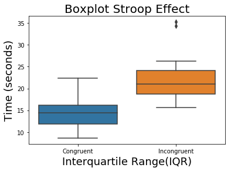

```python
ax = sn.boxplot(data = stroop, order=['Congruent', 'Incongruent'])
plt.title('Boxplot Stroop Effect',fontsize=20)
plt.xlabel('Interquartile Range(IQR)',fontsize=18)
plt.ylabel('Time (seconds)',fontsize=18)
plt.show()
```

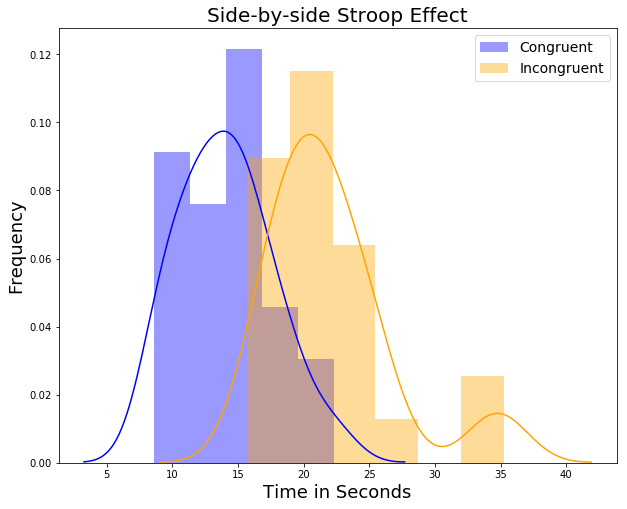

```python
sc = stroop['Congruent']
si = stroop['Incongruent']
plt.subplots(figsize=(10,8))
sn.distplot(sc, color = 'blue');
sn.distplot(si, color = 'orange');
plt.title('Side-by-side Stroop Effect',fontsize=20)
plt.legend(['Congruent', 'Incongruent'],fontsize=14);
plt.xlabel('Time in Seconds',fontsize=18)
plt.ylabel('Frequency',fontsize=18)
plt.show()
```

```python
print(stroop.describe())
```

```
       Congruent  Incongruent
count  24.000000    24.000000
mean   14.051125    22.015917
std     3.559358     4.797057
min     8.630000    15.687000
25%    11.895250    18.716750
50%    14.356500    21.017500
75%    16.200750    24.051500
max    22.328000    35.255000
```

In the histograms above, we can clearly see a shift in the time taken between the congruent list and the incongruent list. The subjects average time(mean) to speak the word is 14.05 seconds for the congruent list. While the average time(mean) to speak the incongruent word is 22.02 seconds. The apex of each histogram shows the middle(median) response times to be 14.36 for congruent and 21.02 for incongruent. The mode, or most common value, is a bit trickier to determine. Because the test calculates the results down to the thousandth of a second, each value is unique and therefore each is the mode. If we reduce the data to whole numbers we see that the mode for congruent returns a range of values (12, 15). The results for incongruent values show 21 as the most common.

```python
scround = sc.round(0)
siround = si.round(0)
print('Median\nCongruent',sc.median(),'\nIncongruent',si.median(),'\n')
print('Mode\nCongruent\n',scround.mode(),'\n\nIncongruent\n',siround.mode())
```

```
Median
Congruent 14.3565
Incongruent 21.0175

Mode
Congruent
 0    12.0
1    15.0
dtype: float64

Incongruent
 0    21.0
dtype: float64
```

```python
print('Unrounded Mode Results\n\n',stroop.mode())
```

```
Unrounded Mode Results

     Congruent  Incongruent
0       8.630       15.687
1       8.987       17.394
2       9.401       17.425
3       9.564       17.510
4      10.639       17.960
5      11.344       18.644
6      12.079       18.741
7      12.130       19.278
8      12.238       20.330
9      12.369       20.429
10     12.944       20.762
11     14.233       20.878
12     14.480       21.157
13     14.669       21.214
14     14.692       22.058
15     15.073       22.158
16     15.298       22.803
17     16.004       23.894
18     16.791       24.524
19     16.929       24.572
20     18.200       25.139
21     18.495       26.282
22     19.710       34.288
23     22.328       35.255
```

The results of the boxplot and histogram support the use of a one-tailed test. Their results suggest that the null hypothesis may be rejected. This one-tailed t-test will be a dependent test because both samples use the same population and each result is directly related to the other.

### Results

#### t(23) = 8.04, p < .025, one-tailed. At $\alpha =$.05 and a Confidence Interval on the mean difference(7.97); 95% CI = (5.92, 10.01).

The p-value is significantly smaller than our alpha level at a 95% Confidence Interval which indicates that we should reject the null hypothesis in favor of the alternative hypothesis. This is futher supported by the **r2** value which shows a very strong correlation at 74%.  
**r2** = $\frac{t^2}{t^2 + df}$ = .74  
**t-statistic** = 8.04  
**T-critical** = 1.174  
**n** = $\mu$ = 24  
**df** = $n-$1 = 23  
**sd** =$\sqrt \frac{\sum d^2 -\frac{\sum (d)^2} {n}}{n-1}$ = 4.86  
**Standard Error of Differences** =$\frac{sd}{\sqrt n}$ = 0.99

The mean difference is calulated by taking sum of the difference between the congruent($\mu_c$) and incongruent($\mu_i$) datasets divided **n**. This further supports a rejection of the null hypothesis and indicates that there is a significant increase in the response time of the subject with the incongruent test.  
**Mean difference** ($\bar{x}$) = $\frac {\sum (\mu_i - \mu_c)} {n}$ = 7.97

### Conclusions

The resultant data clearly shows that once the treatment effect was applied, the subject's reaction time significantly increased. Therefore, I reject the null hypothesis in favor of the alternative hypothesis. The results were not at all unexpected. When we challenge our brains to process information in new ways there is a significant learning curve to overcome to become proficient. The Stroop Effect t-test results clearly support this.

## Sources

[Stroop Effect](https://en.wikipedia.org/wiki/Stroop_effect)

[Testing a Hypothesis for Dependent and Independent Samples](https://www.ck12.org/book/CK-12-Probability-and-Statistics-Advanced-Second-Edition/section/8.5/)

[Code Visibility](http://chris-said.io/2016/02/13/how-to-make-polished-jupyter-presentations-with-optional-code-visibility/)